# Nextflow Basics

## Software engineering for data science

- Challenges

[figure not shown]

  - Workflows / Pipelines consist of different tools
  - dozens of individual methods
  - Software dependencies
  - Complex dependency trees and configuration requirements
  - HPC resource management
  - Scalability - performance optimization
  - Reproduce results with older data / integrate with newer data

## Challenges / Solution

`When faced with a challenge,`  
`look for a way not for a way out`  
David L. Weatherford

A custom DSL (domain-specific language) for building reproducible computational workflows and pipelines

## Nextflow - Features

`Nextflow is built around the concept that`  
`Linux is the lingua franca of data science`

it allows:

- Fast prototyping
  - write a computational pipeline by making it simpler to put together many different tasks
  - reuse your existing scripts and tools
  - **extend** with a powerful **DSL**
  - “no” need to learn a new language or API

## Nextflow - Features

- Reproducibility and isolation of dependencies
  - supports **Docker** and **Singularity** containers technology
  - supports **Conda** envs: easy and automatic software installation
  - integration of the **GitHub** code sharing platform

```
process {
  conda 'bwa samtools multiqc'
  ...
}
```

```
process {
  container 'quay.io/biocontainers/bedtools:2.30.0--h7d7f7ad_2'
  ...
}
docker.enabled = true
```

```bash
$ nextflow run nextflow-io/hello -r v1.1
```

## Nextflow - Features

it is portable:

- abstraction layer between pipeline’s logic and the execution layer
- can be executed on multiple platforms without changing its code
- SGE, LSF, SLURM, PBS and HTCondor batch schedulers
- Kubernetes, Amazon AWS and Google Cloud platforms.

```
process {
  executor = 'sge'
  queue = 'long.q'

  cpus = 2
}
```

## Nextflow - Features

it has *unified parallelism*:

- based on the dataflow programming model
- greatly simplifies writing complex distributed pipelines
- Parallelisation is implicitly defined by the processes input and output declarations.
- The resulting applications are inherently parallel and can scale-up or scale-out

it comes with *continuous checkpoints*:

- all the intermediate results are automatically tracked
- can resume from the last successfully executed step

## Nextflow - Basics

Processes

- A Nextflow pipeline is joining together different processes
- A process can be written in any scripting language (Bash, Perl, Ruby, Python, etc.)
- Processes are executed independently and are isolated from each other, i.e. they do not share a common (writable) state.

## Nextflow - Basics

Channels

- Processes communicate is via asynchronous FIFO queues, called channels in Nextflow.
- Any process can define one or more channels as input and output.
- The interaction between these processes, and ultimately the pipeline execution flow itself, is implicitly defined by these input and output declarations.
- Parallelisation is implicitly defined by the processes input and output declarations

## Nextflow - Basics

Execution abstraction

- A process defines what command or script has to be executed
- The executor determines how it is run on the target system
- By default processes are executed on the local computer (good for testing)
- real world computational pipelines run on an HPC or cloud platform
- Nextflow provides an abstraction between the pipeline and the underlying execution system.

## Nextflow - Basics

Execution abstraction

- Write a pipeline once and seamlessly run it on your computer, a grid platform, or the cloud, without modifying it, by simply defining the target execution platform in the configuration file.

Nextflow supports:

- SGE, LSF, SLURM, PBS, Torque, HTCondor
- Amazon Web Services (AWS), Google Cloud Platform (GCP), Kubernetes

## Nextflow - Basics

Scripting language

- Nextflow is designed to have a minimal learning curve
- In most cases, standard scripting skills to develop Nextflow workflows are fine.
- It also provides a powerful scripting DSL.
- Nextflow scripting is an extension of Groovy, which is a super-set of Java

```
x = Math.random()
if( x < 0.5 ) {
    println "You lost."
}
else {
    println "You won!"
}
```

## Nextflow - Basics

Configuration options

- Pipeline configuration is defined in `nextflow.config`

e.g. : executors, containers/Envs, environment variables, pipeline parameters etc.

```
params {
  resultDir = "/data/results"
  genome = "/data/hg38/genome.fasta"
}
process {
  withName:BWA {
    cpus = 8
    container = "quay.io/biocontainers/bwa:0.7.17--h5bf99c6_8"
  }
}
singularity {
    enabled = true
}
```

## Nextflow - Example

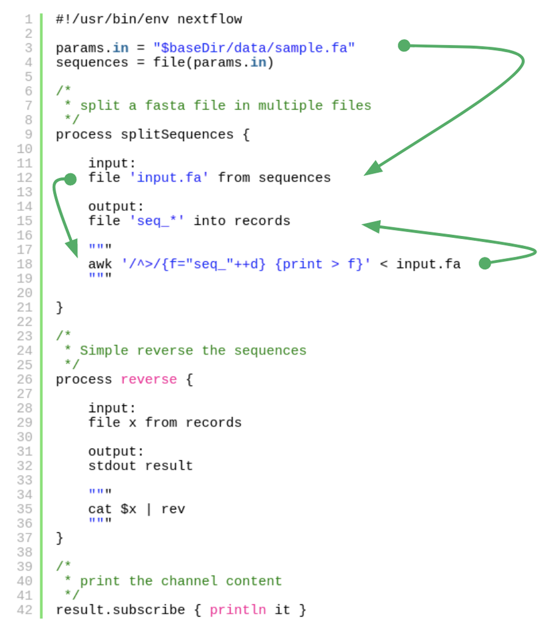

## Nextflow - Example

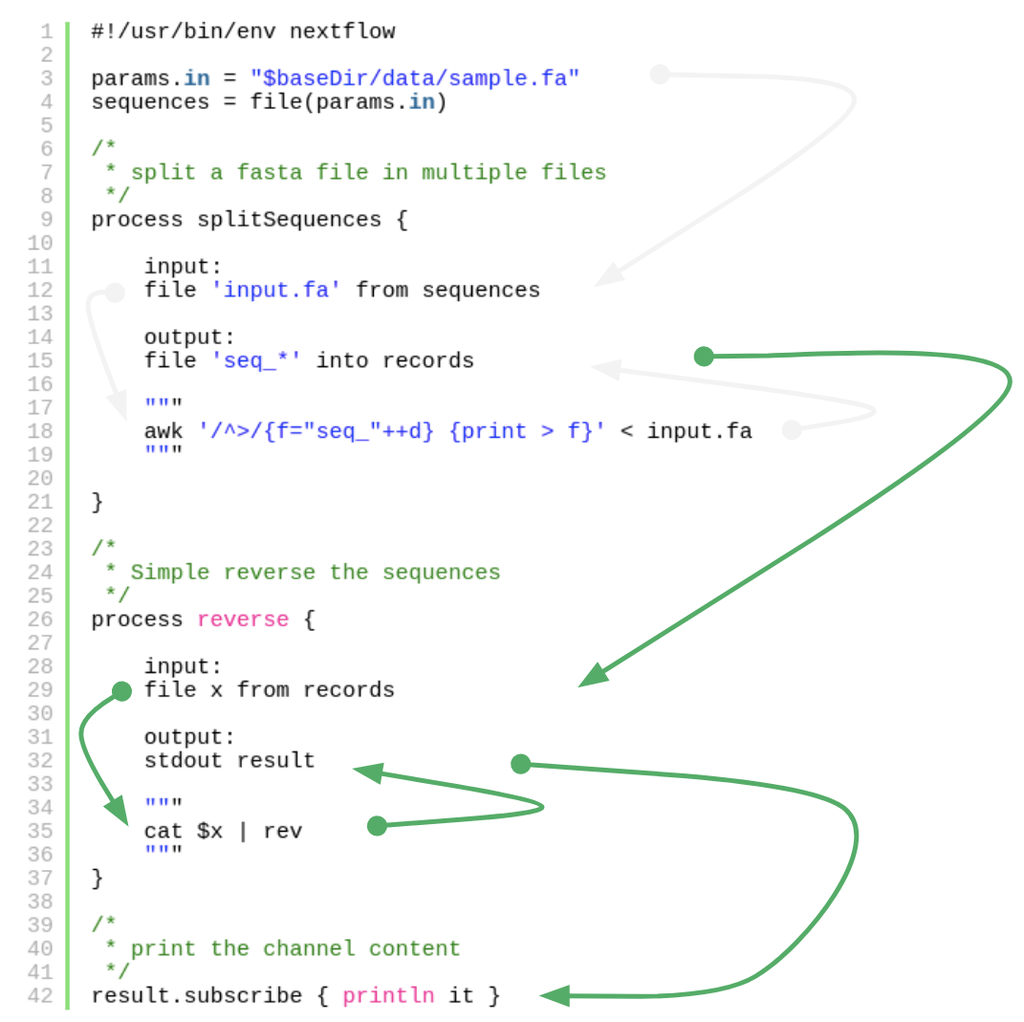

## Nextflow - Links

Documentation:

- https://www.nextflow.io/docs/

Learning:

- https://www.nextflow.io/blog/2020/learning-nextflow-in-2020.html

Pipeline repositories:

- https://nf-co.re/

[figure not shown]

- https://gitlab.i-med.ac.at/icbi-lab/pipelines